# 데이터마이닝_2주차 클린업_코드실습

- 2주차에 배운 내용 중 클러스터링에 대해 간단한 실습을 진행해보겠습니다.
- 가장 생소하셨던 DBSCAN을 중심으로 간단하게만 적어봤으니 편하게 보시면 좋을 거 같아요!
- 클러스터 시각화 & 실루엣 계수 시각화에 대한 함수는 이번 코드에 나오는 사용자 함수를 기억해두셨다가  
  주제분석에서 필요할 때 그대로 갖다쓰시면 편할 것 같습니다!

## 1. DBSCAN 알고리즘

### (1) 데이터 준비

이번에도 Iris 예제 데이터를 사용하겠습니다.

- iris data는 붓꽃 데이터셋으로, 5개의 변수에 대한 관측값 150개가 들어있습니다
- 꽃잎의 길이, 꽃잎의 너비, 꽃받침의 너비, 꽃받침의 길이를 활용해 꽃의 품종(species)을 예측(분류)해볼 수 있습니다
- 우리가 실제로 주제분석을 할 때도 아래와 같이 데이터프레임을 구축한 뒤 분석을 진행하게 될 것입니다

```python
from sklearn.datasets import load_iris # 붓꽃 데이터 로드

import matplotlib.pyplot as plt # 라이브러리 로드
import numpy as np
import pandas as pd
%matplotlib inline

iris = load_iris()
feature_names = ['sepal_length','sepal_width','petal_length','petal_width']

# 우리는 DataFrame을 더 자주 다룰 것이므로 DataFrame 형태로 변환해서 진행하겠습니다
irisDF = pd.DataFrame(data=iris.data, columns=feature_names)
irisDF['target'] = iris.target
```

### (2) 클러스터링

- `eps` : 엡실론 반경
- `min_samples` : minPts

위 두 하이퍼파라미터는 사용자가 정해줘야 한다고 했던 거 기억나시죠?

```python
from sklearn.cluster import DBSCAN # DBSCAN 라이브러리

dbscan = DBSCAN(eps=0.6, min_samples=8, metric='euclidean')

# 지도학습에서는 fit한 모델로 test data에 predict를 수행했다면
# 비지도학습은 정답이 없으므로 바로 fit_predict 메서드를 사용하면 됩니다
dbscan_labels = dbscan.fit_predict(iris.data)
```

```python
# fit_predict의 결과를 dataframe으로 만들어서 확인해봅시다!
irisDF['dbscan_cluster'] = dbscan_labels
irisDF['target'] = iris.target

# target(꽃 품종 3가지)별로 어느 군집에 할당되었는지 봅시다!
iris_result = irisDF.groupby(['target'])['dbscan_cluster'].value_counts()
print(iris_result)
```

```
target  dbscan_cluster
0        0                49
        -1                 1
1        1                46
        -1                 4
2        1                42
        -1                 8
Name: dbscan_cluster, dtype: int64
```

**🌟클러스터링 결과를 보니, `0` 또는 `1` 또는 `-1` 로 할당이 되었네요!**

- 이때, `-1` 군집은 **noise cluster**입니다! DBSCAN은 노이즈를 굳이 특정 군집에 넣지 않는다고 했던 게 이 부분에서 확인됩니다
- 그러면 실질적으로는 `0` 또는 `1`의 2가지 클러스터로 구분했네요
- 실제 타깃 종류는 3가지인데, 변수들을 넣어보니 2개의 군집으로 묶였네요! (이게 꼭 나쁜 건 아닙니다! 오히려 2개로 묶인 만큼 추가적인 인사이트를 얻을 수도 있겠죠!)

### (3) 클러스터링 시각화

- 실제로 군집이 어떤 식으로 묶여있는지 2차원 평면에서 확인해봅시다!
- 그런데 보통 우리가 가진 x변수는 2개보다 많습니다. 그래서 PCA로 압축을 한 뒤 시각화를 진행하게 됩니다.

```python
### 먼저, 클러스터 결과를 2차원에 시각화해주는 함수를 정의합시다!
# 클러스터링 모델, 클러스터링 결과 데이터프레임, 클러스터링 결과가 담긴 열 >>> 순서대로 넣어주면 되는 함수입니다

def visualize_cluster_plot(clusterobj, dataframe, label_name, iscenter=True):
    if iscenter :
        centers = clusterobj.cluster_centers_

    unique_labels = np.unique(dataframe[label_name].values)
    markers=['o', 's', '^', 'x', '*']
    isNoise=False

    for label in unique_labels:
        label_cluster = dataframe[dataframe[label_name]==label]
        if label == -1:
            cluster_legend = 'Noise'
            isNoise=True
        else :
            cluster_legend = 'Cluster '+str(label)

        plt.scatter(x=label_cluster['x1'], y=label_cluster['x2'], s=70,\
                    edgecolor='k', marker=markers[label], label=cluster_legend)

        if iscenter:
            center_x_y = centers[label]
            plt.scatter(x=center_x_y[0], y=center_x_y[1], s=250, color='white',
                        alpha=0.9, edgecolor='k', marker=markers[label])
            plt.scatter(x=center_x_y[0], y=center_x_y[1], s=70, color='k',\
                        edgecolor='k', marker='$%d$' % label)
    if isNoise:
        legend_loc='upper center'
    else: legend_loc='upper right'

    plt.legend(loc=legend_loc)
    plt.show()
```

```python
from sklearn.decomposition import PCA # 이제 PCA를 해보면,,

# 2차원으로 시각화하기 위해 n_componets=2로 데이터 세트를 압축합니다
pca = PCA(n_components=2, random_state=123)
pca_transformed = pca.fit_transform(iris.data) # 압축한 것을 따로 객체에 넣어주고요

# PCA 변환값을 '클러스터링 결과 데이터프레임'에 추가해줍니다
irisDF['x1'] = pca_transformed[:,0]
irisDF['x2'] = pca_transformed[:,1]

irisDF # 잘 추가된 것을 확인할 수 있죠?
```

|  | sepal_length | sepal_width | petal_length | petal_width | target | dbscan_cluster | x1 | x2 |
| --- | --- | --- | --- | --- | --- | --- | --- | --- |
| 0 | 5.1 | 3.5 | 1.4 | 0.2 | 0 | 0 | -2.684126 | 0.319397 |
| 1 | 4.9 | 3.0 | 1.4 | 0.2 | 0 | 0 | -2.714142 | -0.177001 |
| 2 | 4.7 | 3.2 | 1.3 | 0.2 | 0 | 0 | -2.888991 | -0.144949 |
| 3 | 4.6 | 3.1 | 1.5 | 0.2 | 0 | 0 | -2.745343 | -0.318299 |
| 4 | 5.0 | 3.6 | 1.4 | 0.2 | 0 | 0 | -2.728717 | 0.326755 |
| ... | ... | ... | ... | ... | ... | ... | ... | ... |
| 145 | 6.7 | 3.0 | 5.2 | 2.3 | 2 | 1 | 1.944110 | 0.187532 |
| 146 | 6.3 | 2.5 | 5.0 | 1.9 | 2 | 1 | 1.527167 | -0.375317 |
| 147 | 6.5 | 3.0 | 5.2 | 2.0 | 2 | 1 | 1.764346 | 0.078859 |
| 148 | 6.2 | 3.4 | 5.4 | 2.3 | 2 | 1 | 1.900942 | 0.116628 |
| 149 | 5.9 | 3.0 | 5.1 | 1.8 | 2 | 1 | 1.390189 | -0.282661 |

150 rows × 8 columns

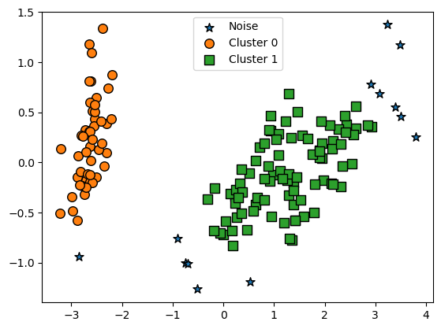

```python
# 그리고 만들어둔 함수에 필요 성분들을 입력해서, 시각화를 합니다
visualize_cluster_plot(dbscan, irisDF, 'dbscan_cluster', iscenter=False)
```

**이렇게 표현해보니 각 군집과 노이즈들이 더 잘 보이네요!**

- 이때, 초록색에 가까운 별들 일부가 노이즈로 빠지지 않기를 원한다면, eps를 좀 더 크게 바꿔볼 수도 있습니다!
- 또는, min_samples를 크게 해서 더 밀도가 높은 데이터들만 모이도록 (기준을 더 깐깐하게) 할 수도 있습니다!

각각에 대해서 간단히 확인해보겠습니다!

① eps에 변화 주기

```python
## 우측 상단에 cluster1과 가까운 노이즈 5개 정도는 다시 군집으로 들어올 수 있도록 하고 싶습니다!
## 그러면 말했듯이 eps 반경을 좀 더 키워서 더 많은 데이터가 군집에 들어가도록 해보겠습니다!

dbscan = DBSCAN(eps=0.8, min_samples=8, metric='euclidean') # 다 똑같고, 여기 eps만 바꾸면 됩니당
dbscan_labels = dbscan.fit_predict(iris.data)

irisDF['dbscan_cluster'] = dbscan_labels
irisDF['target'] = iris.target

iris_result = irisDF.groupby(['target'])['dbscan_cluster'].value_counts()
print(iris_result) # 오 결과가 뭔가 다르게 나온 거 같군요
```

```
target  dbscan_cluster
0        0                50
1        1                50
2        1                47
        -1                 3
Name: dbscan_cluster, dtype: int64
```

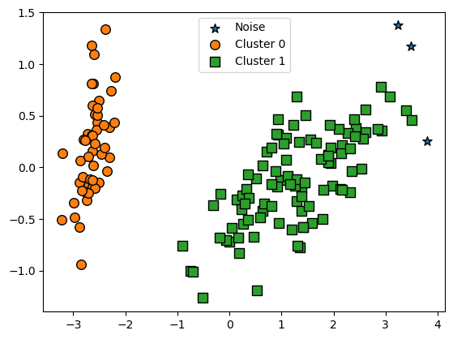

```python
visualize_cluster_plot(dbscan, irisDF, 'dbscan_cluster', iscenter=False)
# 그리고 다시 그려보면, 애매했던 노이즈들이 cluster1로 들어갔네요!
```

② min_samples에 변화 주기

```python
# 역시 다 똑같고, hyperparameter에 넣는 값만 바꿔주면 됩니다!

dbscan = DBSCAN(eps=0.6, min_samples=16, metric='euclidean')
dbscan_labels = dbscan.fit_predict(iris.data)

irisDF['dbscan_cluster'] = dbscan_labels
irisDF['target'] = iris.target

iris_result = irisDF.groupby(['target'])['dbscan_cluster'].value_counts()
print(iris_result)
```

```
target  dbscan_cluster
0        0                48
        -1                 2
1        1                44
        -1                 6
2        1                36
        -1                14
Name: dbscan_cluster, dtype: int64
```

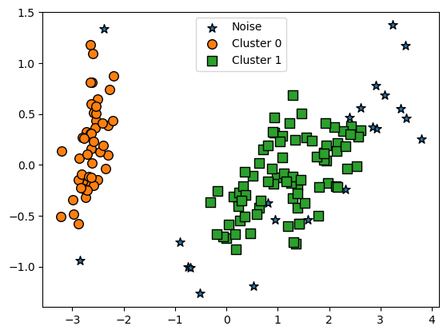

```python
# 더 깐깐하게 클러스터링한 만큼, 노이즈들이 더 많아진 것이 보이네요!
visualize_cluster_plot(dbscan, irisDF, 'dbscan_cluster', iscenter=False)
```

## 2. DBSCAN과 타 클러스터링 비교

- DBSCAN의 장점을 얘기할 때, KMeans가 파악하지 못하는 밀도나 특수한 형태를 잡을 수 있다고 했습니다.
- 이를 확인하기 위해 특정한 기하적 분포를 갖는 데이터셋으로 비교해보겠습니다

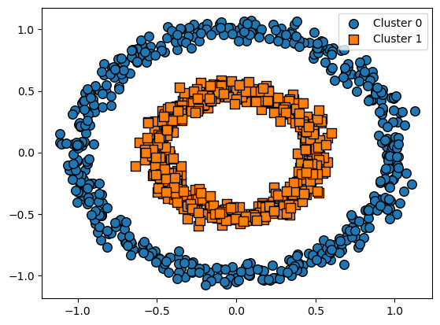

```python
# 원형으로 예제 데이터셋을 생성할 수 있습니다! 이걸로 실험해보죠!
from sklearn.datasets import make_circles

# (make_circles 함수는 무조건 2개의 변수만 생성하므로, 우리가 따로 설정해주지 않아도 됩니다)
X, y = make_circles(n_samples=1000, shuffle=True, noise=0.05, random_state=0, factor=0.5)
clusterDF = pd.DataFrame(data=X, columns=['x1', 'x2'])
clusterDF['target'] = y

# 아까 만든 사용자 함수로 실제 클러스터를 그려보면 이런 느낌이네요!
visualize_cluster_plot(None, clusterDF, 'target', iscenter=False)
```

### ① KMeans

먼저 KMeans로 시도해보겠습니다

```python
from sklearn.cluster import KMeans

kmeans = KMeans(n_clusters=2, max_iter=1000, random_state=0) # 정답을 알고 있으니 k=2로 설정하겠습니다 (알려줘도 어차피 못 맞춰요..ㅎㅎ)
kmeans_labels = kmeans.fit_predict(X) # 역시 fit_predict를 수행하고
clusterDF['kmeans_cluster'] = kmeans_labels

clusterDF # 결과를 뽑아볼 수 있습니다!
```

|  | x1 | x2 | target | kmeans_cluster |
| --- | --- | --- | --- | --- |
| 0 | 0.519781 | -0.015981 | 1 | 0 |
| 1 | -0.057719 | -0.420279 | 1 | 0 |
| 2 | -0.805155 | -0.662227 | 0 | 0 |
| 3 | 0.316549 | 0.312730 | 1 | 1 |
| 4 | -0.304804 | 0.407563 | 1 | 1 |
| ... | ... | ... | ... | ... |
| 995 | -0.222906 | -0.326809 | 1 | 0 |
| 996 | -0.766648 | 0.677558 | 0 | 1 |
| 997 | -0.012036 | 0.396755 | 1 | 1 |
| 998 | 0.398129 | 0.318982 | 1 | 1 |
| 999 | -0.366066 | 0.339589 | 1 | 1 |

1000 rows × 4 columns

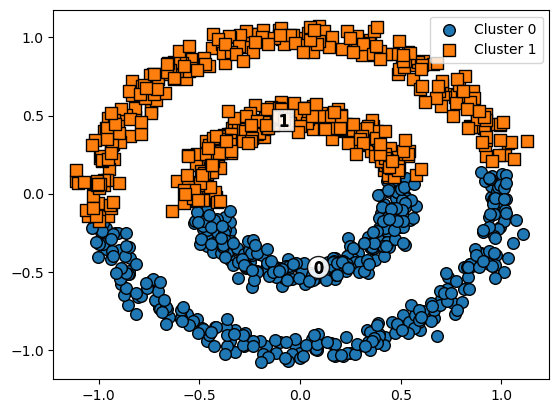

```python
# 그런데 시각화를 해보면,,
visualize_cluster_plot(kmeans, clusterDF, 'kmeans_cluster', iscenter=True)
```

😥 처참하군요

- 정답에 맞는 k=2로 설정하고 수행했음에도, 특정한 형태를 전혀 잡아내지 못하는 게 보입니다.

### ② GMM

원형 거리를 기반으로 잡아내는 KMeans의 한계를 극복할 수 있는 GMM으로도 시도해보겠습니다  
GMM은 아래 사진처럼 일렬로 늘어선 군집의 경우를 잘 잡습니다!

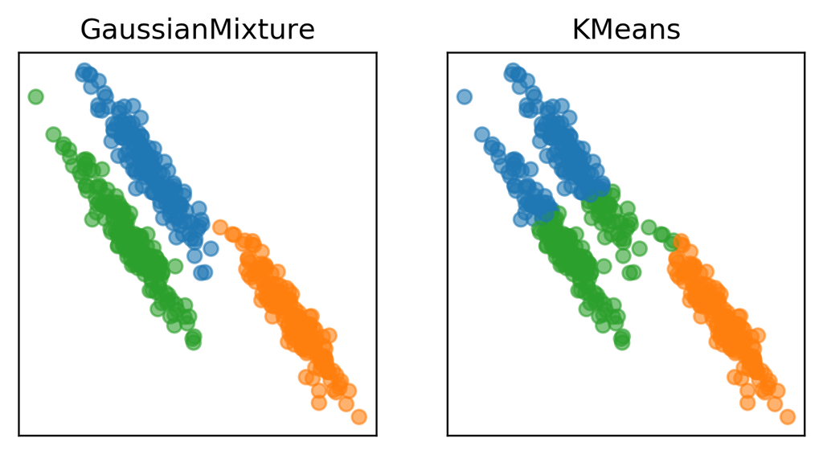

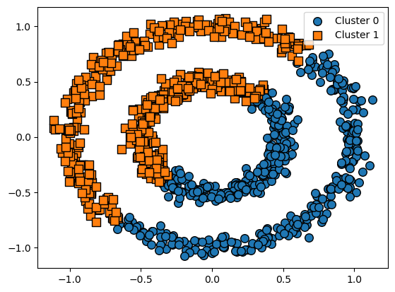

```python
from sklearn.mixture import GaussianMixture

gmm = GaussianMixture(n_components=2, random_state=0)
gmm_label = gmm.fit(X).predict(X)
clusterDF['gmm_cluster'] = gmm_label
# 이번엔 결과를 따로 뽑아보진 않고, 바로 시각화해보겠습니다
visualize_cluster_plot(gmm, clusterDF, 'gmm_cluster', iscenter=False)
```

😥 이런.. GMM도 이건 못 잡는군요

- 정답에 맞는 k=2로 설정하고 수행했음에도, 특정한 형태를 전혀 잡아내지 못하는 게 보입니다.

### ③ DBSCAN

이제 밀도기반의 DBSCAN을 써봅시다!

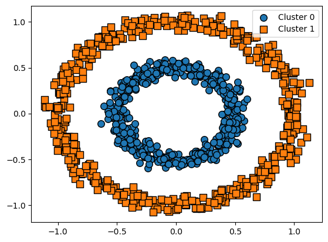

```python
from sklearn.cluster import DBSCAN

dbscan = DBSCAN(eps=0.2, min_samples=10, metric='euclidean')
dbscan_labels = dbscan.fit_predict(X)
clusterDF['dbscan_cluster'] = dbscan_labels
# 역시 바로 시각화만 해보겠습니다
visualize_cluster_plot(dbscan, clusterDF, 'dbscan_cluster', iscenter=False)
```

😋 잘 잡네요! 이렇게 밀도 차이가 있거나 특수한 형태를 띠는 데이터일 때는 DBSCAN을 고려해봅시다!

## 3. 클러스터링 평가 by Silhouette Method

- 위에서 쓴 붓꽃 데이터에 대해 실루엣 계수들을 구해보고, 이를 활용해 적절한 클러스터 개수를 찾아봅시다!
- 클러스터링은 그냥 KMeans로 간단하게 해보겠습니다
  - `iter`는 초기 centroid 설정 방식을 지정하는 변수인데, `'k-means++'`는 랜덤보다 좀 더 똑똑하게 수행합니다!  
    근데 KMeans 함수도 그걸 기본값으로 하고 있어서 따로 지정 안 해도 되긴 합니다 (자세한 내용은 [링크](https://itstory1592.tistory.com/19)로 첨부할게요)
  - 그리고 교안에서도 얘기했듯이 일정 iteration을 반복하면 멈추게 할 수도 있는데, 그게 `max_iter` 변수입니다!

```python
from sklearn.metrics import silhouette_samples, silhouette_score # 실루엣 계수 계산을 위한 api를 추가해주겠습니다
import matplotlib.pyplot as plt
import numpy as np
import pandas as pd

# iris = load_iris()
# feature_names = ['sepal_length','sepal_width','petal_length','petal_width']
# irisDF = pd.DataFrame(data=iris.data, columns=feature_names)

# 가장 간단한 KMeans를 쓰겠습니다. 군집 개수는 3으로 하고요!
kmeans = KMeans(n_clusters=3, init='k-means++', max_iter=300,random_state=0).fit(irisDF)
irisDF['cluster'] = kmeans.labels_

irisDF # 결과표를 뽑아보면 cluster들이 잘 할당되었음을 알 수 있네요
```

|  | sepal_length | sepal_width | petal_length | petal_width | target | dbscan_cluster | x1 | x2 | cluster |
| --- | --- | --- | --- | --- | --- | --- | --- | --- | --- |
| 0 | 5.1 | 3.5 | 1.4 | 0.2 | 0 | 0 | -2.684126 | 0.319397 | 1 |
| 1 | 4.9 | 3.0 | 1.4 | 0.2 | 0 | 0 | -2.714142 | -0.177001 | 1 |
| 2 | 4.7 | 3.2 | 1.3 | 0.2 | 0 | 0 | -2.888991 | -0.144949 | 1 |
| 3 | 4.6 | 3.1 | 1.5 | 0.2 | 0 | 0 | -2.745343 | -0.318299 | 1 |
| 4 | 5.0 | 3.6 | 1.4 | 0.2 | 0 | 0 | -2.728717 | 0.326755 | 1 |
| ... | ... | ... | ... | ... | ... | ... | ... | ... | ... |
| 145 | 6.7 | 3.0 | 5.2 | 2.3 | 2 | 1 | 1.944110 | 0.187532 | 2 |
| 146 | 6.3 | 2.5 | 5.0 | 1.9 | 2 | 1 | 1.527167 | -0.375317 | 0 |
| 147 | 6.5 | 3.0 | 5.2 | 2.0 | 2 | 1 | 1.764346 | 0.078859 | 2 |
| 148 | 6.2 | 3.4 | 5.4 | 2.3 | 2 | 1 | 1.900942 | 0.116628 | 2 |
| 149 | 5.9 | 3.0 | 5.1 | 1.8 | 2 | 1 | 1.390189 | -0.282661 | 0 |

150 rows × 9 columns

- `silhouette_samples` 함수를 이용하면 개별 데이터의 실루엣 계수를 구할 수 있습니다
- 그리고 `silhouette_score` 함수를 쓰면, 모든 데이터의 실루엣 계수를 평균 낸 최종 score를 뽑아줍니다

```python
# 개별 데이터의 실루엣 계수값을 구해보면
score_samples = silhouette_samples(iris.data, irisDF['cluster'])
print('silhouette_samples() 결과값의 shape =' , score_samples.shape) # 150개 샘플에 대해서 다 구해준 것을 볼 수 있네요
```

```
silhouette_samples() 결과값의 shape = (150,)
```

```python
# 계산한 실루엣 계수들을 결과표에 넣어주겠습니다 ('silhouette_coeff' 컬럼으로 추가)
irisDF['silhouette_coeff'] = score_samples
irisDF.head() # 잘 나오네요
```

|  | sepal_length | sepal_width | petal_length | petal_width | target | dbscan_cluster | x1 | x2 | cluster | silhouette_coeff |
| --- | --- | --- | --- | --- | --- | --- | --- | --- | --- | --- |
| 0 | 5.1 | 3.5 | 1.4 | 0.2 | 0 | 0 | -2.684126 | 0.319397 | 1 | 0.853307 |
| 1 | 4.9 | 3.0 | 1.4 | 0.2 | 0 | 0 | -2.714142 | -0.177001 | 1 | 0.816080 |
| 2 | 4.7 | 3.2 | 1.3 | 0.2 | 0 | 0 | -2.888991 | -0.144949 | 1 | 0.829863 |
| 3 | 4.6 | 3.1 | 1.5 | 0.2 | 0 | 0 | -2.745343 | -0.318299 | 1 | 0.805723 |
| 4 | 5.0 | 3.6 | 1.4 | 0.2 | 0 | 0 | -2.728717 | 0.326755 | 1 | 0.849674 |

```python
# 그리고 모든 데이터의 평균 실루엣 계수값을 구해보면
average_score = silhouette_score(iris.data, irisDF['cluster'])
print('최종 실루엣 점수 : {0:.3f}'.format(average_score)) # 0.5 정도로 양호하게 나옵니다.
```

```
최종 실루엣 점수 : 0.552
```

```python
# 그런데 군집별로 그룹화해서 출력해보니,,
irisDF.groupby('cluster')['silhouette_coeff'].mean() # 그룹마다 꽤 차이가 나네요?
# 그러니 시각화를 해봅시다!!
```

```
cluster
0    0.415775
1    0.798662
2    0.451496
Name: silhouette_coeff, dtype: float64
```

### 🌟실루엣 시각화 함수

아래 함수는 사이킷런 공식 문서에서 제공하는 소스코드를 활용해, 클러스터 개수를 바꿔가며 KMeans를 수행할 수 있는 함수를 만든 것입니다.  
이 함수를 활용하면 다른 클러스터링에 대해서도 실루엣 점수를 시각화할 수 있습니다!

```python
import pandas as pd
import numpy as np
import matplotlib.pyplot as plt
from sklearn.cluster import KMeans
from sklearn.metrics import silhouette_samples, silhouette_score
from sklearn.datasets import load_iris

def visualize_silhouette(data, cluster_range):
    feature_names = ['sepal_length', 'sepal_width', 'petal_length', 'petal_width'] # 다른 데이터셋을 쓸 거면 이 부분을 수정!
    data_df = pd.DataFrame(data=data, columns=feature_names)

    num_plots = len(cluster_range)
    num_cols = 4  # 4개씩 가로로 출력하도록 설정
    num_rows = int(np.ceil(num_plots / num_cols))

    plt.figure(figsize=(16, num_rows * 4))

    for i, n_clusters in enumerate(cluster_range):
        plt.subplot(num_rows, num_cols, i + 1)
        # KMeans 말고 다른 클러스터링을 쓸 것 같으면 이 부분을 수정!
        kmeans = KMeans(n_clusters=n_clusters, init='k-means++', max_iter=300, random_state=0)
        cluster_labels = kmeans.fit_predict(data_df)

        silhouette_avg = silhouette_score(data_df, cluster_labels)
        sample_silhouette_values = silhouette_samples(data_df, cluster_labels)

        y_lower = 10
        for j in range(n_clusters): # 클러스터 개수별로 그래프 그리기
            ith_cluster_silhouette_values = sample_silhouette_values[cluster_labels == j]
            ith_cluster_silhouette_values.sort()

            size_cluster_j = ith_cluster_silhouette_values.shape[0]
            y_upper = y_lower + size_cluster_j

            color = plt.cm.get_cmap("Spectral")(float(j) / n_clusters)
            plt.fill_betweenx(np.arange(y_lower, y_upper), 0, ith_cluster_silhouette_values, facecolor=color, edgecolor=color, alpha=0.7)
            plt.text(-0.05, y_lower + 0.5 * size_cluster_j, str(j))
            y_lower = y_upper + 10

        plt.title("Silhouette plot for {} clusters\nAvg Silhouette Score: {:.4f}".format(n_clusters, silhouette_avg))
        plt.xlabel("Silhouette coefficient values")
        plt.ylabel("Cluster label")

        plt.axvline(x=silhouette_avg, color="red", linestyle="--")
        plt.yticks([])  # Clear the y-axis labels
        plt.xticks([-0.1, 0, 0.2, 0.4, 0.6, 0.8, 1])

    plt.tight_layout()
    plt.show()
```

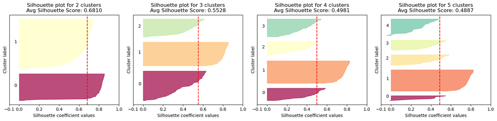

```python
# 이런 식으로, 데이터와 클러스터 개수 후보만 입력해주면, 알아서 KMeans를 수행하고 실루엣 계수를 산출해줍니다!
visualize_silhouette(iris.data, [2,3,4,5])
```

클러스터 몇 개가 가장 좋아보이나요? 아까 위에서 DBSCAN 때도 얘기했지만, 이 경우에는 클러스터를 2개로 하는 것이 가장 좋아보입니다.  
3개의 경우는 최종 score도 낮을 뿐더러, 0,2 cluster와 1 cluster간의 편차가 너무 큽니다!  
(실제 타깃은 3종류라고 할지라도 말이죠. 더군다나, 우리는 실제로 타깃이 몇 종류인지 알 수 없습니다..)  
이런 식으로 시각화를 해보면서 적절한 군집을 찾는 연습을 해보면, 주제분석 때도 분명 유용하게 쓰일 거예요 :)

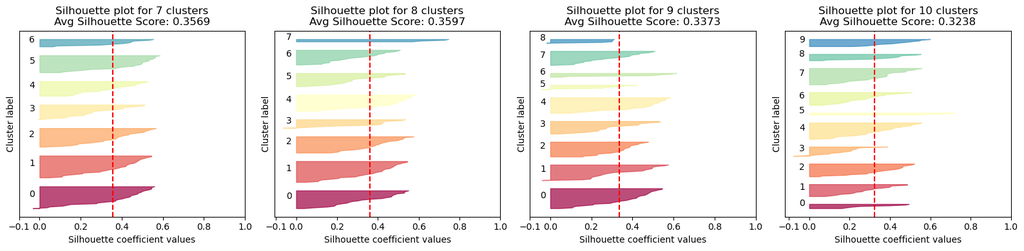

```python
# 몇 개만 더 해볼까요?
visualize_silhouette(iris.data, [7,8,9,10])
```

클러스터 개수를 아예 늘려봤더니 전체적으로 평균을 넘긴 하지만, 최종 점수 자체가 0.3밖에 안 되네요!  
k를 지정해줘야 하는 KMeans 등의 클러스터링을 쓸 때는, 이렇게 다방면으로 validity measure를 확인하면서 최적의 k를 찾는 것이 좋습니다.

## 4. 클러스터링의 활용

- 추가로, 실제 비즈니스 의사결정과 연결되는 사례를 잘 설명해둔 자료가 있어 공유합니다!
- 코드도 친절하게 설명되어 있으니 궁금하신 분은 이것도 직접 해보시면 좋을 거 같네요

https://suy379.tistory.com/51#Tech_34._%ED%81%B4%EB%9F%AC%EC%8A%A4%ED%84%B0%EB%A7%81_%EA%B2%B0%EA%B3%BC_%EC%8B%9C%EA%B0%81%ED%99%94(%EC%B0%A8%EC%9B%90_%EC%B6%95%EC%86%8C_%ED%99%9C%EC%9A%A9)